# Dow Data Challenge: Clustering

### CHE 891 — Week 1

We apply **K-means** and **hierarchical clustering** to the unfiltered Dow training data to see whether unsupervised methods reveal the same operational anomalies identified by PCA in the Week 1 notebook.

> **Note:** We use only the basic cleaning steps here (replacing bad values, dropping mostly-missing rows, and interpolating). We intentionally skip the PCA-based outlier filtering so the clusters can reveal the anomalies for us.

```python
import pandas as pd
import numpy as np
from pylab import *
from matplotlib.ticker import MaxNLocator
from datetime import datetime

from sklearn.preprocessing import StandardScaler
from sklearn.decomposition import PCA
from sklearn.cluster import KMeans
from sklearn.metrics import silhouette_score
from scipy.cluster.hierarchy import dendrogram, linkage, fcluster
from sklearn.cluster import AgglomerativeClustering

import warnings
warnings.filterwarnings('ignore')
```

## 1. Load and Clean Data

Same loading and basic cleaning as Week 1. We stop before the PCA-based outlier filtering.

```python
url = 'http://egr.msu.edu/~scb/courses/EGR891/ImpurityDataset_Training.xlsx'
df = pd.read_excel(url)

# Replace '!' with NaN
for col in df.columns:
    if df[col].astype(str).str.contains('!').any():
        df[col] = pd.to_numeric(df[col].mask(df[col] == '!'), errors='coerce')

# Drop rows that are >50% missing, then interpolate
df = df.dropna(thresh=int(0.5 * len(df.columns)), axis=0)
df = df.interpolate()
df = df.reset_index(drop=True)

print(f"Dataset shape: {df.shape}")
df.head(3)
```

```
Dataset shape: (10684, 46)
```

|  | Date | x1:Primary Column Reflux Flow | x2:Primary Column Tails Flow | x3:Input to Primary Column Bed 3 Flow | x4:Input to Primary Column Bed 2 Flow | x5:Primary Column Feed Flow from Feed Column | x6:Primary Column Make Flow | x7:Primary Column Base Level | x8:Primary Column Reflux Drum Pressure | x9:Primary Column Condenser Reflux Drum Level | ... | x36: Feed Column Recycle Flow | x37: Feed Column Tails Flow to Primary Column | x38: Feed Column Calculated DP | x39: Feed Column Steam Flow | x40: Feed Column Tails Flow | Avg_Reactor_Outlet_Impurity | Avg_Delta_Composition Primary Column | y:Impurity | Primary Column Reflux/Feed Ratio | Primary Column Make/Reflux Ratio |
| --- | --- | --- | --- | --- | --- | --- | --- | --- | --- | --- | --- | --- | --- | --- | --- | --- | --- | --- | --- | --- | --- |
| 0 | 2015-12-01 00:00:00 | 327.813 | 45.7920 | 2095.06 | 2156.01 | 98.5005 | 95.4674 | 54.3476 | 41.0121 | 52.2353 | ... | 62.8707 | 45.0085 | 66.6604 | 8.68813 | 99.9614 | 5.38024 | 1.49709 | 1.77833 | 3.32803 | 0.291226 |
| 1 | 2015-12-01 01:00:00 | 322.970 | 46.1643 | 2101.00 | 2182.90 | 98.0014 | 94.9673 | 54.2247 | 41.0076 | 52.5378 | ... | 62.8651 | 45.0085 | 66.5496 | 8.70683 | 99.8637 | 5.33345 | 1.51392 | 1.76964 | 3.29556 | 0.294044 |
| 2 | 2015-12-01 02:00:00 | 319.674 | 45.9927 | 2102.96 | 2151.39 | 98.8229 | 96.0785 | 54.6130 | 41.0451 | 52.0159 | ... | 62.8656 | 45.0085 | 66.0599 | 8.69269 | 100.2490 | 5.37677 | 1.50634 | 1.76095 | 3.23481 | 0.300552 |

3 rows × 46 columns

```python
X = df.loc[:, 'x1:Primary Column Reflux Flow':'x40: Feed Column Tails Flow'].values
Y = df.loc[:, 'y:Impurity'].values
dates = df['Date']
print(f"X shape: {X.shape}")
```

```
X shape: (10684, 40)
```

## 2. Standardize Features

Always scale before clustering — sensors have very different units and ranges.

```python
scaler = StandardScaler()
X_scaled = scaler.fit_transform(X)   # <- you, using StandardScaler
```

## 3. PCA — 2-D Projection for Visualization

We compute a 2-component PCA **only for plotting** cluster membership. The clustering itself runs on the full 40-feature scaled space.

```python
pca2 = PCA(n_components=2)
X_pca2 = pca2.fit_transform(X_scaled)
var = pca2.explained_variance_ratio_
print(f"PC1: {var[0]:.1%}  PC2: {var[1]:.1%}  Total: {sum(var):.1%}")
```

```
PC1: 58.6%  PC2: 10.4%  Total: 69.0%
```

## 4. K-Means Clustering

### 4.1 Initial Fit

Start with $k = 3$ or $4$ to get a feel for the cluster structure, then we will optimize $k$ in section 4.3.

```python
k = 4   # <- you: start with 3 or 4

km = KMeans(n_clusters=k, random_state=42, n_init=10)
km_labels = km.fit_predict(X_scaled)

print(f"Cluster sizes: {dict(zip(*np.unique(km_labels, return_counts=True)))}")
```

```
Cluster sizes: {np.int32(0): np.int64(4190), np.int32(1): np.int64(6022), np.int32(2): np.int64(250), np.int32(3): np.int64(222)}
```

### 4.2 Visualize Clusters

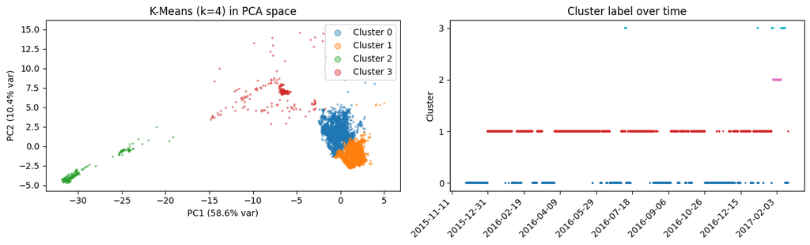

```python
fig, axes = subplots(1, 2, figsize=(13, 4))

# PCA scatter
for c in range(k):
    mask = km_labels == c
    axes[0].scatter(X_pca2[mask, 0], -X_pca2[mask, 1],
                    s=3, alpha=0.4, label=f'Cluster {c}')
axes[0].set_xlabel(f'PC1 ({var[0]:.1%} var)')
axes[0].set_ylabel(f'PC2 ({var[1]:.1%} var)')
axes[0].set_title(f'K-Means (k={k!r}) in PCA space')
axes[0].legend(markerscale=4, loc='upper right')

# Time series
axes[1].scatter(dates, km_labels, s=1, c=km_labels, cmap='tab10')
axes[1].set_ylabel('Cluster')
axes[1].set_yticks(range(k))
axes[1].set_title('Cluster label over time')
axes[1].xaxis.set_major_locator(MaxNLocator(nbins=12))
setp(axes[1].xaxis.get_majorticklabels(), rotation=45, ha='right')

tight_layout()
show()
```

### 4.3 Optimizing $k$ — Elbow and Silhouette

Fit K-means for a range of $k$ and plot:

- **WCSS** (within-cluster sum of squares) — look for the elbow
- **Silhouette score** — higher is better; a peak suggests optimal $k$

Then go back and update `k` in section 4.1 if needed.

```python
k_range = range(2, 11)
wcss = []
sil  = []

for k in k_range:
    km = KMeans(n_clusters=k, random_state=42, n_init=10)
    labels = km.fit_predict(X_scaled)
    wcss.append(km.inertia_)  # <- you  hint: km.inertia_
    sil.append(silhouette_score(X_scaled,labels))   # <- you  hint: silhouette_score()
```

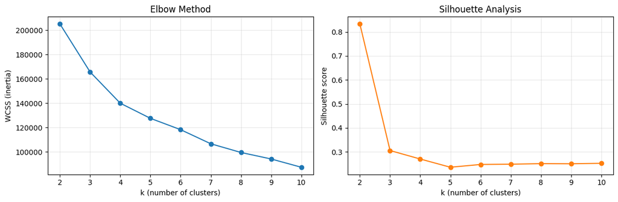

```python
# Visualize how the number of clusters (k) affects WCSS and silhouette score.
fig, axes = subplots(1, 2, figsize=(12, 4))

# Elbow plot: lower WCSS is better, with diminishing returns after the elbow.
axes[0].plot(list(k_range), wcss, marker='o')
axes[0].set_xlabel('k (number of clusters)')
axes[0].set_ylabel('WCSS (inertia)')
axes[0].set_title('Elbow Method')
axes[0].grid(alpha=0.3)

# Silhouette plot: higher is better; peak often indicates a good k.
axes[1].plot(list(k_range), sil, marker='o', color='C1')
axes[1].set_xlabel('k (number of clusters)')
axes[1].set_ylabel('Silhouette score')
axes[1].set_title('Silhouette Analysis')
axes[1].grid(alpha=0.3)

tight_layout()
show()
```

### 4.4 Discussion

> **Q:** Do any clusters correspond to the known anomalies identified in the Week 1 PCA analysis (e.g., the $x_{39}=0$ period, the changed operating conditions from 8/22/2016–12/16/2016)?

*(Your answer below)*

The undesirable spread of data, corresponding with clusters 2 and 3, occur primarily around the date 2017-02-03.

## 5. Hierarchical Clustering

### 5.1 Dendrogram

With ~10,000 samples a full dendrogram is unreadable. We draw it on a random subsample to guide our choice of the number of clusters, then assign all samples using `AgglomerativeClustering`.

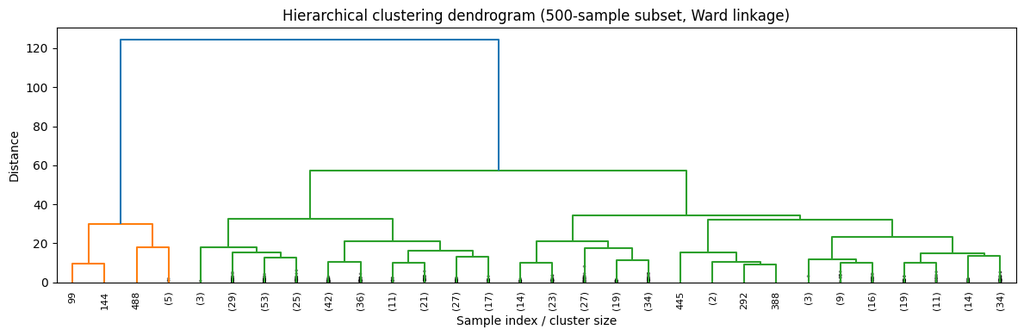

```python
rng = np.random.default_rng(42)
idx_sub = rng.choice(len(X_scaled), size=500, replace=False)
X_sub = X_scaled[idx_sub]

Z = linkage(X_sub, method='ward')

fig, ax = subplots(figsize=(12, 4))
dendrogram(Z, ax=ax, truncate_mode='lastp', p=30,
           leaf_rotation=90, leaf_font_size=8,
           show_contracted=True)
ax.set_title('Hierarchical clustering dendrogram (500-sample subset, Ward linkage)')
ax.set_xlabel('Sample index / cluster size')
ax.set_ylabel('Distance')
tight_layout()
show()
```

### 5.2 Assign Cluster Labels

Cut the dendrogram at a chosen number of clusters and apply to the full dataset.

```python
n_clusters = 7   # <- you: choose based on the dendrogram above

hc = AgglomerativeClustering(n_clusters=n_clusters, linkage='ward')
hc_labels = hc.fit_predict(X_scaled)

print(f"Cluster sizes: {dict(zip(*np.unique(hc_labels, return_counts=True)))}")
```

```
Cluster sizes: {np.int64(0): np.int64(209), np.int64(1): np.int64(84), np.int64(2): np.int64(196), np.int64(3): np.int64(3113), np.int64(4): np.int64(2606), np.int64(5): np.int64(2458), np.int64(6): np.int64(2018)}
```

### 5.3 Visualize

[figure not shown]

```python
# you: Plot each cluster in PCA space and over time.


fig, axes = subplots(1, 2, figsize=(13, 4))

# PCA scatter
for c in range(n_clusters):
    mask = hc_labels == c
    axes[0].scatter(X_pca2[mask, 0], -X_pca2[mask, 1],
                    s=3, alpha=0.4, label=f'Cluster {c}')
axes[0].set_xlabel(f'PC1 ({var[0]:.1%} var)')
axes[0].set_ylabel(f'PC2 ({var[1]:.1%} var)')
axes[0].set_title(f'K-Means (k={k!r}) in PCA space')
axes[0].legend(markerscale=4, loc='upper right')

# Time series
axes[1].scatter(dates, hc_labels, s=1, c=hc_labels, cmap='tab10')
axes[1].set_ylabel('Cluster')
axes[1].set_yticks(range(n_clusters))
axes[1].set_title('Cluster label over time')
axes[1].xaxis.set_major_locator(MaxNLocator(nbins=12))
setp(axes[1].xaxis.get_majorticklabels(), rotation=45, ha='right')

tight_layout()
show()
```

## 5B. Hierarchical Clustering (Date-Stratified Subsample)

Repeat cells 22–26, but build the dendrogram from a subsample stratified over time so all periods are represented.

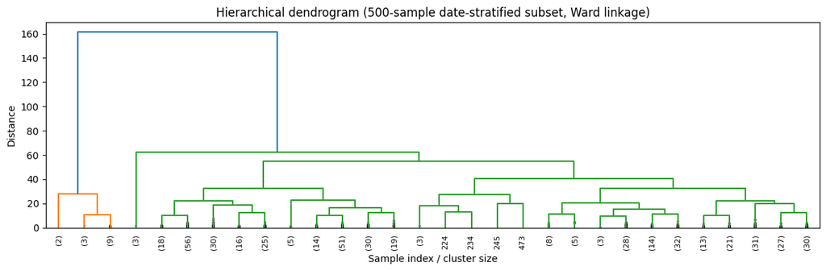

```python
rng = np.random.default_rng(42)

# Convert to datetime and create 10 chronological bins (deciles in time).
dates_dt = pd.to_datetime(dates)
time_bins = pd.qcut(dates_dt.rank(method='first'), q=10, labels=False)

# Stratified sample size target (same size as the random-subsample dendrogram).
n_sub = 500

# Sample roughly equal counts from each time bin so the full date span is represented.
idx_strat = []
for b in np.sort(np.unique(time_bins)):
    idx_bin = np.where(time_bins == b)[0]
    take = min(len(idx_bin), int(np.ceil(n_sub / len(np.unique(time_bins)))))
    idx_strat.extend(rng.choice(idx_bin, size=take, replace=False))

# Trim to exactly n_sub points if we overshoot.
idx_strat = np.array(idx_strat[:n_sub])
X_sub_strat = X_scaled[idx_strat]

# Ward-linkage dendrogram on date-stratified subsample.
Z_strat = linkage(X_sub_strat, method='ward')

fig, ax = subplots(figsize=(12, 4))
dendrogram(Z_strat, ax=ax, truncate_mode='lastp', p=30,
           leaf_rotation=90, leaf_font_size=8,
           show_contracted=True)
ax.set_title('Hierarchical dendrogram (500-sample date-stratified subset, Ward linkage)')
ax.set_xlabel('Sample index / cluster size')
ax.set_ylabel('Distance')
tight_layout()
show()
```

### 5B.2 Assign Cluster Labels

Use the same cluster count as section 5.2, but keep labels separate for comparison.

```python
n_clusters_strat = n_clusters

hc_strat = AgglomerativeClustering(n_clusters=n_clusters_strat, linkage='ward')
hc_labels_strat = hc_strat.fit_predict(X_scaled)

print(f"Date-stratified cluster sizes: {dict(zip(*np.unique(hc_labels_strat, return_counts=True)))}")
```

```
Date-stratified cluster sizes: {np.int64(0): np.int64(209), np.int64(1): np.int64(84), np.int64(2): np.int64(196), np.int64(3): np.int64(3113), np.int64(4): np.int64(2606), np.int64(5): np.int64(2458), np.int64(6): np.int64(2018)}
```

### 5B.3 Visualize

Plot the date-stratified hierarchical labels in PCA space and over time.

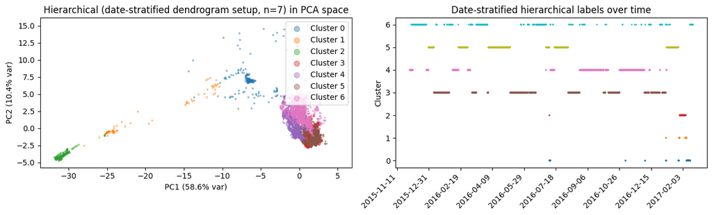

```python
fig, axes = subplots(1, 2, figsize=(13, 4))

# PCA scatter
for c in range(n_clusters_strat):
    mask = hc_labels_strat == c
    axes[0].scatter(X_pca2[mask, 0], -X_pca2[mask, 1],
                    s=3, alpha=0.4, label=f'Cluster {c}')
axes[0].set_xlabel(f'PC1 ({var[0]:.1%} var)')
axes[0].set_ylabel(f'PC2 ({var[1]:.1%} var)')
axes[0].set_title(f'Hierarchical (date-stratified dendrogram setup, n={n_clusters_strat}) in PCA space')
axes[0].legend(markerscale=4, loc='upper right')

# Time series
axes[1].scatter(dates, hc_labels_strat, s=1, c=hc_labels_strat, cmap='tab10')
axes[1].set_ylabel('Cluster')
axes[1].set_yticks(range(n_clusters_strat))
axes[1].set_title('Date-stratified hierarchical labels over time')
axes[1].xaxis.set_major_locator(MaxNLocator(nbins=12))
setp(axes[1].xaxis.get_majorticklabels(), rotation=45, ha='right')

tight_layout()
show()
```

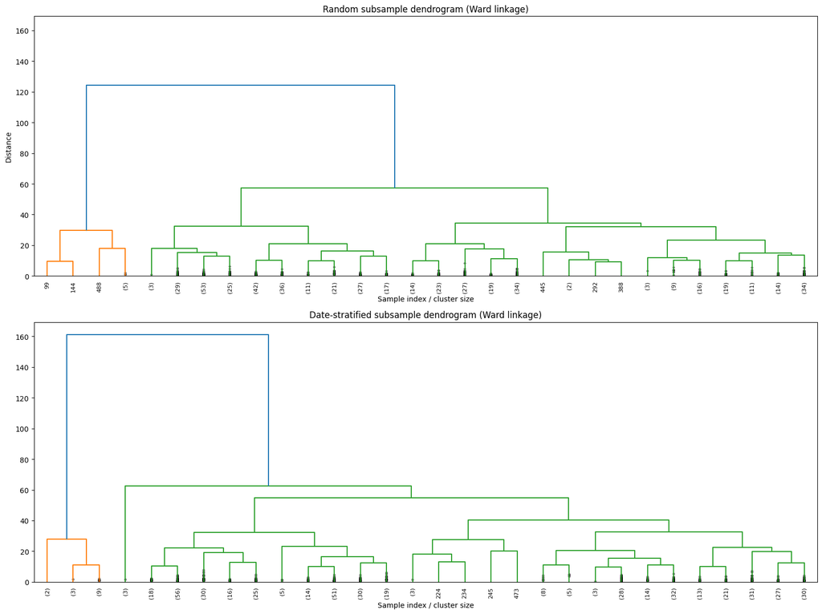

```python
# Side-by-side comparison of the two dendrograms:
# - Left: random 500-point subsample (Z)
# - Right: date-stratified 500-point subsample (Z_strat)
fig, axes = subplots(2,1, figsize=(16,12), sharey=True)

# Random-subsample dendrogram
dendrogram(Z, ax=axes[0], truncate_mode='lastp', p=30,
           leaf_rotation=90, leaf_font_size=8,
           show_contracted=True)
axes[0].set_title('Random subsample dendrogram (Ward linkage)')
axes[0].set_xlabel('Sample index / cluster size')
axes[0].set_ylabel('Distance')

# Date-stratified dendrogram
dendrogram(Z_strat, ax=axes[1], truncate_mode='lastp', p=30,
           leaf_rotation=90, leaf_font_size=8,
           show_contracted=True)
axes[1].set_title('Date-stratified subsample dendrogram (Ward linkage)')
axes[1].set_xlabel('Sample index / cluster size')

tight_layout()
show()
```

## 6. Column Clustering — Grouping Sensors

Clustering the **features** (columns) rather than samples reveals which sensors move together — useful for understanding process topology and for variable selection. The correlation matrix is a natural distance metric for this.

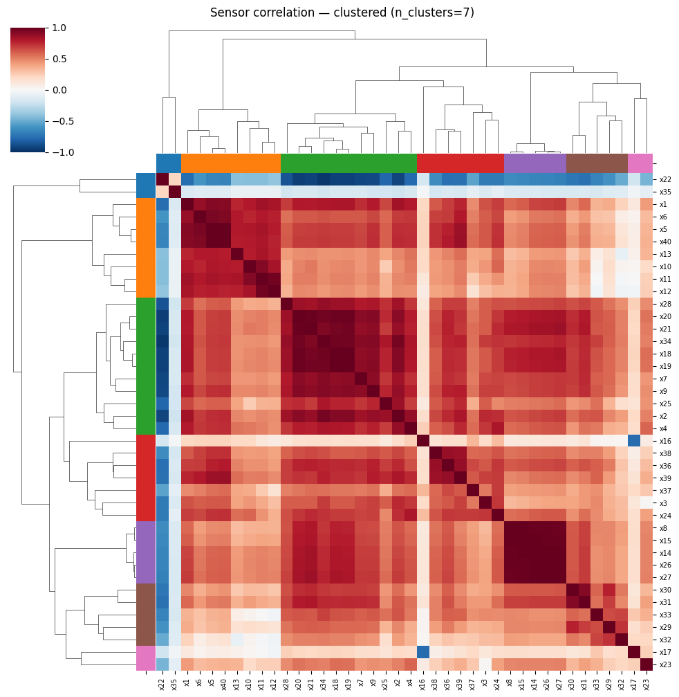

```python
import seaborn as sns

dfX_scaled = pd.DataFrame(
    X_scaled,
    columns=df.loc[:, 'x1:Primary Column Reflux Flow':'x40: Feed Column Tails Flow'].columns,
)

# Sensor-to-sensor correlation matrix (features clustered, not samples).
corr = dfX_scaled.corr()
short_X_names = [c.split(':')[0] for c in corr.columns]

# Build a feature linkage tree and cut it into the user-selected number of clusters.
# This makes the correlation plot explicitly respect `n_clusters`.
Z_feat = linkage(dfX_scaled.T, method='ward')
feature_cluster_ids = fcluster(Z_feat, t=n_clusters, criterion='maxclust')

# Color bars to show cluster membership for each sensor on both axes.
palette = sns.color_palette('tab10', n_colors=n_clusters)
feature_colors = [palette[cid - 1] for cid in feature_cluster_ids]
row_col_colors = pd.Series(feature_colors, index=corr.index)

g = sns.clustermap(
    corr,
    cmap='RdBu_r',
    vmin=-1,
    vmax=1,
    xticklabels=short_X_names,
    yticklabels=short_X_names,
    figsize=(10, 10),
    row_linkage=Z_feat,
    col_linkage=Z_feat,
    row_colors=row_col_colors,
    col_colors=row_col_colors,
    linewidths=0,
)
g.fig.suptitle(f'Sensor correlation — clustered (n_clusters={n_clusters})', y=1.01)
g.ax_heatmap.tick_params(labelsize=7)
show()
```

### 6.1 Discussion

> **Q:** Do the sensor clusters correspond to physical subsystems in the Dow process (e.g., Primary Column pressures, Secondary Column temperatures)? Compare with the process diagram and sensor list from the slides.

*(Your answer here)*

The sensor clusters correspond to individual sensing elements at certain points in the process; these elements have some overlap or redundancy, but are not always active.

Can we identify similar issues to PCA?

Clustering shows that there is considerable overlap between sensors, and including all of this information is going to increase out chances of overfitting without improving the overall accuracy of our ML model.